# Part II - (FordGoBike System Data)

## by (Taiwo Olorunsogbon)

## Investigation Overview

> In this investigation, I wanted to look at to the customer behaviour characteristics, I focused on time, age, gender, duration, and user type to analyze and understand the usage of bike When, Who, How?

## Dataset Overview

> This data set includes information about individual rides made in a bike-sharing system covering the greater San Francisco Bay area.

## (Visualization 1)

### Number of Bike ride for member user type

> In our dataset there are two type of user:
- Subscriber
- Customer In the next visualization I will show the volumn of bike rides for all members user type

*In the dataset, there are more Subscriber than Customers.*

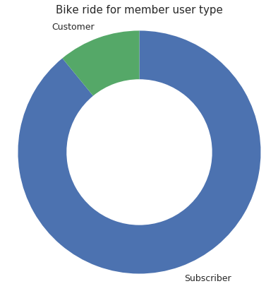

## (Visualization 2)

### The Daily Usage of Bike Rides Per Gender

> Based on our data we have three gender male, female and other. In the next visualization I will show the number of bike rides for each day based on gender

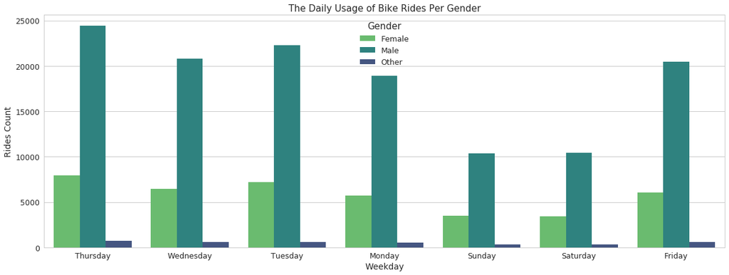

## (Visualization 3)

### Bike Rides for User Types per Members Age Categories

The visualization will show the number of bike rides for the user types based on the different age categories

I divided members age into 5 categories.

- 11-20
- 21-30
- 31-40
- 41-50
- 51-60

*So, I will show number of bike rides per category by the user type.*

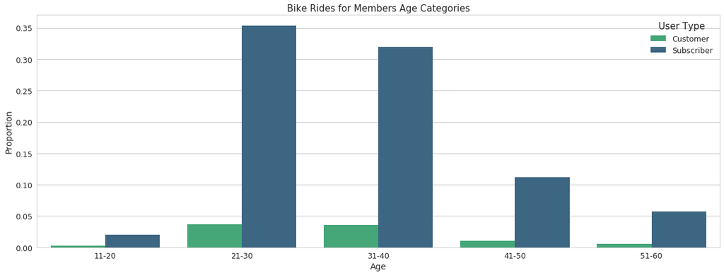

## (Visualization 4)

### The Daily Usage of Bike Rides by weekday

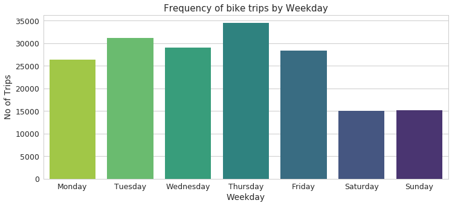

## (Visualization 5)

### Correlation between each variables

*In this visualization, I want show the correlation between each variables in the dataset*

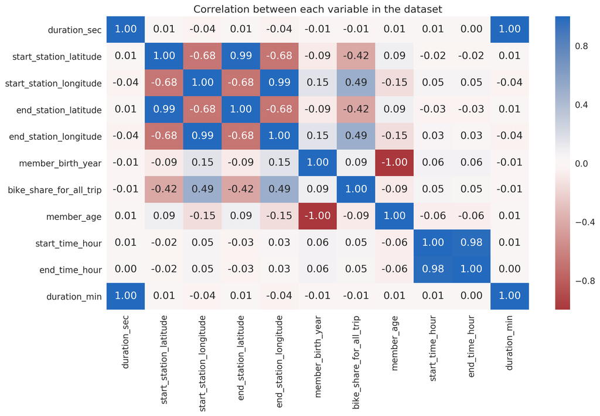